# Tango

Chaccour and Brew

[figure not shown]

Tango. It’s an intricate and complex dance, with high levels of coordination and timing between different roles (dancers, bandoleon, and other musicians). It’s also the tentative name of this project: an intricate, complex attempt at [“the dance”](https://medium.com/@tomaspueyo/coronavirus-the-hammer-and-the-dance-be9337092b56), ie the long-term effort to control COVID-19 until there’s a vaccine.

In scientific lingo, we might call this project something like “Guding post-lockdown COVID-19 confinement policies through an assessment of spatial-temporal heterogeneity in population vulnerability and receptivity”.

## The concepts

### A. Receptivity and vulnerability

We borrow two concepts from the world of [malaria research](https://www.who.int/malaria/mpac/mpac-april2019-session7-report-erg-malariogenic-potential.pdf?ua=1):

1. Receptivity: how “well-suited” an area is for high-risk cases
2. Vulnerability: the frequency of influx of infected individuals or groups

Understanding the concept through examples:

- An rural village with a young, healty population would be:
  - Low receptivity (not many people who are likely to develop a severe case)
  - Low vulnerability
- A coastal town with a high prevalence of elderly retirees:
  - High receptivity (many people predisposed to a severe case due to age)
  - High vulnerability (high risk of disease “importation” due to tourist movement)
- A commuter town with a close proximity to an urban center would be:
  - Low receptivity (mostly working-age people below age of highest-risk)
  - High vulnerability (lots of movement to and from other areas)
- An isolated mountain town with an elderly population might be:
  - High receptivity (many people predisposed to severe illness due to age)
  - Low vulnerability (very little in/out flow)

### B. Susceptibility and spatial-temporal infection risk

Neither receptivity nor vulnerability can be understood in a vacuum. Both require incorporating the concepts of susceptibility and spatial-temporal infection risk

1. Susceptibility: how much of the population remains uninfected and is therefore susceptible to becoming infected and infectious
2. Spatial-temporal risk: how much disease activity is there nearby (understanding “nearby” to be a function of actual flows of human mobility, not simple linear distance) at the time in question

### Integrating the concepts: an index

We propose a risk “index”, which takes into account all four of the aforementioned concepts:

- A1. Receptivity
- A2. Vulnerability
- B1. Susceptibility
- B2. Spatial-temporal risk

Once constructed, this index serves to determine the level of “loosening” of social distancing measures so as to (i) minimize loss of life and health, (ii) maximize social and economic activity, and (iii) implement the *correct* degree of disease control measures (ie, robust enough to prevent contagion, but not overly robust so as to restrict human activity or lead to poor compliance).

## Work-flow

- A1. Receptivity: We can assess this right now with publicly available census data (see below)
- A2. Vulnerability: We can assess this right now, roughly, by a simple flow matrix based on population density (ie, we assume flows are between unpopulated areas and more densely populated areas)
- B1. Susceptibility: We need to carry out mass serology, sampling a random but significantly large percentage of the at-risk population in every municipality
- B2. Spatial-temporal risk: We need a constant flow of epidemiological data (similar to what the Ministry publishes now, but at the municipality level)

# Receptivity

First, we’ll prepare data for analysis.

```r
# Load the package for this project
library(tango)
# Load other useful packages
library(knitr)
library(tidyr)
library(dplyr)
library(sp)
library(ggplot2)
library(RColorBrewer)

# Get census age data
census <- tango::census
# Get municipios spatial data
municipios <- tango::municipios
```

We’ll define a function for getting “receptivity” (ie, age-based risk) for each municipality. In this first iteration, we’ll just set it as the percentage of people who are above age `n`

```r
define_receptivity <- function(data, n){
  data %>%
    mutate(receptive = edad >= n) %>%
    summarise(pop_receptive = sum(total[receptive], na.rm = TRUE),
              total_pop = sum(total, na.rm = TRUE)) %>%
    ungroup %>%
    mutate(p_receptive = pop_receptive / total_pop * 100)
}
```

We then define receptivity for each municipio in Spain, with an age cut-off of, for example, 80 years:

```r
risks <- census %>%
  group_by(municipio, id) %>%
  define_receptivity(n = 80) %>%
  arrange(desc(p_receptive))
```

Let’s take a peak at the most “receptive” municipalities (ie, those whose populations are most pre-disposed to severe cases):

```r
risks %>% head %>% kable
```

| municipio | id | pop_receptive | total_pop | p_receptive |
| --- | --- | --- | --- | --- |
| Riba de Escalote, La | 42157 | 10 | 18 | 55.55556 |
| Olmeda de la Cuesta | 16140 | 18 | 37 | 48.64865 |
| Ciruelos del Pinar | 19089 | 16 | 34 | 47.05882 |
| Valdemadera | 26161 | 4 | 9 | 44.44444 |
| Tormellas | 05244 | 28 | 65 | 43.07692 |
| Tórtoles | 05246 | 30 | 73 | 41.09589 |

The below shows the distribution of percentage of people 80 or older by municipality.

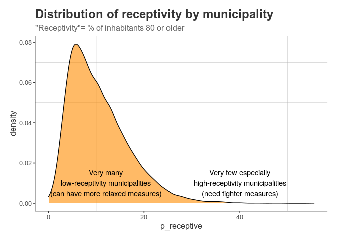

```r
ggplot(data = risks,
       aes(x = p_receptive)) +
  geom_density(fill = 'darkorange', alpha = 0.6) +
  theme_simple() +
  geom_text(data = tibble(x = c(12, 40),
                          y = c(0.01, 0.01),
                          label = c('Very many\nlow-receptivity municipalities\n(can have more relaxed measures)',
                                      'Very few especially\nhigh-receptivity municipalities\n(need tighter measures)')),
            aes(x = x, y = y, label = label)) +
  labs(title = 'Distribution of receptivity by municipality',
       subtitle = '"Receptivity"= % of inhabitants 80 or older')
```

Let’s think of this another way. If we created an arbitrary cut-off for relaxing certain measures at, for example, a receptivity of 25% or lower, we would see:

```r
x = risks %>%
  group_by(status = ifelse(p_receptive <= 25, 'Relax', 'No-relax')) %>%
  summarise(municipalities = n(),
            population = sum(total_pop)) %>%
  mutate(percentage = round(population / sum(population) * 100, digits = 2))
names(x) <- Hmisc::capitalize(names(x))
x %>% kable
```

| Status | Municipalities | Population | Percentage |
| --- | --- | --- | --- |
| No-relax | 206 | 18738 | 0.04 |
| Relax | 7910 | 46789993 | 99.96 |

Let’s map receptivity (again, using the 80 years cut-off example).

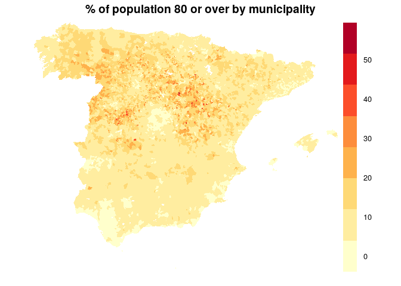

```r
map <- municipios
map@data <- left_join(map@data, risks, by = 'id')
mycolours <- brewer.pal(8, "YlOrRd")
spplot(map, 'p_receptive', par.settings = list(axis.line = list(col ="transparent")), main = "% of population 80 or over by municipality", cuts = 7, col ="transparent", col.regions = mycolours)
```

We can vary a bit. Let’s do 70 years…

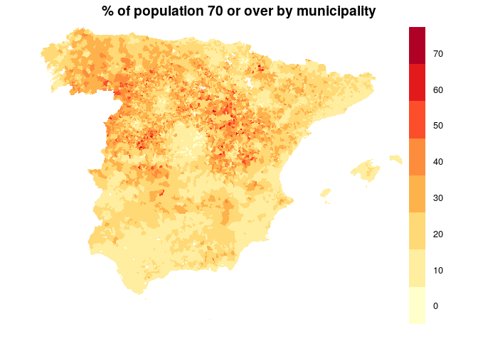

```r
risks <- census %>%
  group_by(municipio, id) %>%
  define_receptivity(n = 70) %>%
  arrange(desc(p_receptive))
map <- municipios
map@data <- left_join(map@data, risks, by = 'id')
mycolours <- brewer.pal(8, "YlOrRd")
spplot(map, 'p_receptive', par.settings = list(axis.line = list(col ="transparent")), main = "% of population 70 or over by municipality", cuts = 7, col ="transparent", col.regions = mycolours)
```

and 60 years…

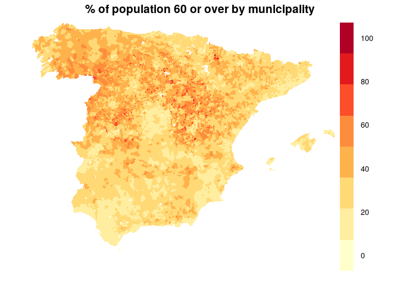

```r
risks <- census %>%
  group_by(municipio, id) %>%
  define_receptivity(n = 60) %>%
  arrange(desc(p_receptive))
map <- municipios
map@data <- left_join(map@data, risks, by = 'id')
mycolours <- brewer.pal(8, "YlOrRd")
spplot(map, 'p_receptive', par.settings = list(axis.line = list(col ="transparent")), main = "% of population 60 or over by municipality", cuts = 7, col ="transparent", col.regions = mycolours)
```

Good. Now we’ve identified especially “receptive” populations (ie, those with an age structure that puts them at risk). Task A1 (1 of 4) done.

Time to do the other three tasks:

- A2. Vulnerability
- B1. Susceptibility
- B2. Spatial-temporal risk

# Vulnerability

For vulnerability, we want to estimate how much movement there is between each municipality and other areas. We could do this with raw data from, for example, mobile networks. But until we have those data, we’ll use a more simple metric: how many nearby population centers of mobile people are there.

Let’s call a population center any place with a population of >5,000 people. And let’s say nearby = 20km. And let’s say “mobile people” are those between ages 18 and 65.

Here are the population centers:

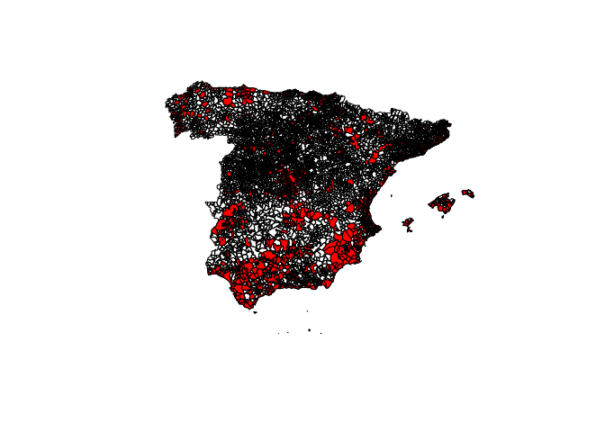

```r
library(geosphere)
# Get cities populations
cities_sp <- census %>%
  filter(edad >= 18,
         edad <= 65) %>%
  group_by(id, municipio) %>%
  summarise(population = sum(total, na.rm = TRUE)) %>%
  ungroup %>%
  filter(population >= 5000)
# Get locations
x <- municipios
x@data <- left_join(x@data, cities_sp)
x <- x[!is.na(x@data$population),]

plot(municipios)
plot(x, add = T, col = 'red')
```

```r
cities_sp <- x
# Define matrix of distances
distances <- geosphere::distm(x = coordinates(municipios),
                              y = coordinates(cities_sp),
                              fun = distHaversine)
distances <- t(distances)
# distances <- rgeos::gDistance(spgeom1 = municipios,
#                               cities_sp,
#                               byid = T)
out <- rep(NA, ncol(distances))
for(j in 1:ncol(distances)){
  this_municipality <- municipios@data$NAMEUNIT[j]
  distance_values <- distances[,j]
  keeps <- which(distance_values < 20000)
  n <- length(keeps)
  out[j] <- n
}
# Now, for every municipality, we have a vulnerability score
map <- municipios
map@data$vulnerability <- sqrt(out)
```

Having calculated vulnerability score, let’s visualize

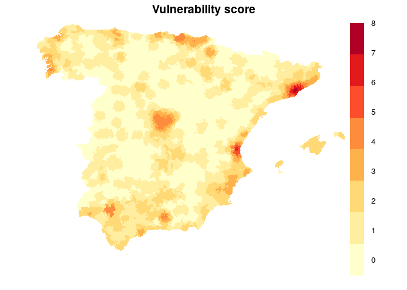

```r
mycolours <- brewer.pal(8, "YlOrRd")
spplot(map, 'vulnerability', par.settings = list(axis.line = list(col ="transparent")), main = "Vulnerability score", cuts = 7, col ="transparent", col.regions = mycolours)
```

Now we can *cross* vulnerability and receptivity, to identify those areas which are most at risk demographically (ie, old) and by virtue of potential mobility (ie, proximity to population centers). Here it is:

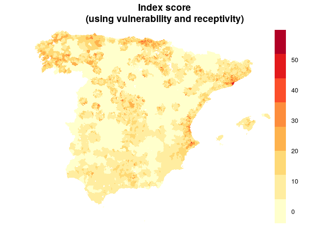

```r
risks <- census %>%
  group_by(municipio, id) %>%
  define_receptivity(n = 80) %>%
  arrange(desc(p_receptive))
map@data <- left_join(map@data, risks, by = 'id')
# Create index based on both vulnerability and receptivity
map@data$index <- map@data$vulnerability * map@data$p_receptive

spplot(map, 'index', par.settings = list(axis.line = list(col ="transparent")), main = "Index score\n(using vulnerability and receptivity)", cuts = 7, col ="transparent", col.regions = mycolours)
```

Great. We have some concept of vulnerability and vulnerability, and we build a basic index on both. We’re two steps in the right direction.

But the index can be improved. Being close to other populations (ie, being “vulnerable”) only matters if those other populations are infectious. Which brings us to our next steps…

# Next steps

What’s next? We need to assess (1) susceptibility and (1) spatial-temporal risk. Urgently

For (1), we need funds and a team to start preparations for mass serology. Sampling strategy and timing will be fundamental to getting actionable data. This will almost certainly be the most expensive, but also most important, part of this work.

For (2), we need the Ministry of Health to release municipality-level data as soon as possible. This should be granular (ie, a dataset with one row per case, with variables including municipality, date of symptom onset, age, sex, place of diagnosis).

# Technical set-up

This analysis is set-up as an R package. One can install it in one of two ways:

1. Clone from https://github.com/joebrew/tango and then build package from source (sequentially walking through the code in `data-raw/update.R` and then running `update.sh` from the command line).
2. In an R session, install the package directly from github: `devtools::install_github('joebrew/tango')`.